# コピュラの金融実務での具体的な活用方法の解説

S.Mori

2019年11月1日

## 1.はじめに

- 金融資産ポートフォリオの価格付やリスク管理ではリスクファクターが多変量分布に従うとして評価
- 各変量の分布：周辺分布
- 周辺分布間の依存構造
- 周辺分布間の依存構造を扱う1つのツール：コピュラ
- コピュラ：多変量分布を周辺分布と依存構造に分離
- 資産担保証券等の、信用リスクを有する多数の企業向け債権を原資産とする商品
- 原資産である各企業向け債権の信用度は互いに依存しているが、マクロ的な不況等の際には、それらの多くが一斉に悪化するような状況

## 2.コピュラ

### (1)コピュラの定義

- スクラー(Sklar)の定理:
- 周辺分布関数$F_1,\cdots,F_n$を持つ連続な$n$変量同時分布関数を$F$とすると、

$$P(X_1<x_1,\cdots,X_n<x_n)=F(x_1,\cdots,x_n)=C(F_1(x_1),\cdots,F_n(x_n)),
\,\,\, (1)$$

- を満たす関数$C$が一意に存在する。$C$がコピュラ.
- $C(F_1,\cdots,F_n)$：周辺分布を区間[0,1]の一様分布とする同時分布関数

$$P(U_1<u_1,\cdots,U_n<u_n)=C(u_1,\cdots,u_n)$$

- $n$変量同時分布関数$F$が周辺分布$F_1,\cdots,F_n$とコピュラ$C$を持つとすると

$$C(u_1,\cdots,u_n)=F(F_1^{-1}(u_1),\cdots,F_n^{-1}(u_n)) \,\,\,(2)$$

- $C$は各周辺分布が$[0,1]$の一様分布となる.
- コピュラの密度関数$c(u_1,\cdots,u_n)=\partial^n C/\partial u_1\cdots\partial u_n$,$X_i$の確率密度関数を$f_i(x_i)$, 同時分布関数$F$の確率密度関数を$f$とすると

$$f(x_1,\cdots,x_n)=c(F_1(x_1),\cdots,F_n(x_n))\prod_{i=1}^{n}f_i(x_i) \,\,\,
(3)$$

$$c(u_1,\cdots,u_n)=f(F_1^{-1}(u_1),\cdots,F_n^{-1}(u_n))\prod_{i=1}^{n}f_{i}^{-1}(F_i^{-1}(u_i))$$

### (2)コピュラの性質：分布の裾での依存関係

- 上側依存係数

$$\lambda_{U}=\lim_{u\to 1^+}P(X_2>F_2^{-1}(u)|X_1> F_{1}^{-1}(u))$$
$$\lambda_{U}=2\lim_{u\to 1^+}P(U_1>u|U_2=u)$$

- 下側裾依存係数

$$\lambda_{L}=\lim_{u\to
0+}P(X_2<F_{2}^{-1}(u)|X_{1}<F_{1}^{-1}(u))=2\lim_{u\to 0^+}
P(U_1<u|U_2<u)$$

### (3)コピュラの性質：順位相関：分布全体での依存の程度

- ケンドールの$\tau$

$$\tau\equiv
P((X_1^i-X_1^j)(X_2^j-X_2^j)>0)-P((X_1^i-X_1^i)(X_2^i-X_2^j)<0)=4\int
\int F(x_1,x_2)dF(x_1,x_2)-1.$$

$$\tau=4\cdot \int_{0}^{1}\int_{0}^{1}C(u_1,u_2)dC(u_1,u_2)-1$$

- スピアマンの$\rho_S$

$$\rho_S \equiv
\frac{\mbox{Cov}(F_1(X_1),F_2(X_2)}{\sqrt{\mbox{V}(F_1(X_1))\mbox{V}(F_2(X_2))}}
=12 \mbox{Cov}(F_1(X_1),F_2(X_2)=12\int\int
|F(x_1,x_2)-F_1(x_1)F_2(x_2)|dF_1(x_1)dF_2(x_2)$$

$$=12\int_{0}^{1}\int_{0}^{1}|C(u_1,u_2)-u_1 u_2|du_1du_2.$$

### (4)コピュラのパラメータ推定

- 対数尤度関数

$$I(\psi_1,\cdots,\psi_n,\vec{a})=\sum_{j=1}^{N}\ln
c((F_1(x_1^j;\psi_1),\cdots,F_n(x_n^j,\psi_n));\vec{a})
+\sum_{j=1}^{n}\sum_{i=1}^{n}\ln f_i(x_i^j;\psi_i)$$

- 周辺分布のパラメータ$\psi_i$を最尤推定し、そのあとでコピュラのパラメータ$\vec{a}$を最尤推定

### (5)コピュラの選択基準

- ヒストリカルデータの経験同時分布とコピュラの同時分布の相違がもっとも少ないもの

$$(x_1^j,\cdots,x_n^j),j=1,\cdots,N$$

- 経験コピュラ
- $x_i^j(j=1,\cdots,N)$を小さい順に並べ$x_i^k$が$r_i^k$番目になったとする.
- $X_i$の周辺経験分布:$P(X_i<x_i^k)=r_i^k/N$
- 経験コピュラ:(t_1/N,,t_n/N)

$$\hat{C}(t_1/N,\cdots,t_n/N)=\frac{1}{N}\sum_{k=1}^{N}\prod_{i=1}^{n}1_{r_{i}^k\le
t_i}\,\,\, (17)$$

- 選択基準：(17)の経験コピュラ$\hat{C}$との相違が最も小さいものを用いる
- 対象とするコピュラの集合$\{C_l\}_{1\le l\le L}$との相違を(18)で定義（Romano[2002])

$$d_n(\hat{C},C_l)=
\sqrt{\sum_{t_i=1}^{N}\cdots\sum_{t_n=1}^{N}[\hat{C}(t1/N,\cdots,t_n/N)-C_l(t_1/N,\cdots,t_n/N)]^2}$$

- 留意点：パラメータ数が同程度(異なるならAICを用いるBreymann[2003])

### (6)コピュラを用いた乱数発生

- $C(u_1,\cdots,u_n)$に従う一様乱数$U_1,\cdots,U_n$の発生は後に解説
- $X_i$の周辺分布が$F_i$のとき

$$X_i=F_i^{-1}(U_i)$$

# 3.正規コピュラとtコピュラ

### (1)正規コピュラ

- 多変量正規分布と同じ依存構造
- 相関行列$\Sigma$の$n$変量標準正規分布$\Phi_n(x_1,\cdots,x_n;\Sigma)$、確率密度関数$\phi_n(x_1,\cdots,x_n;\Sigma)$
- $P(X_1\le x_1,\cdots,X_n\le x_n)=\Phi_n(x_1,\cdots,x_n;\Sigma)$:相関行列$\Sigma$の$n$変量標準正規分布
- スクラーの定理から$C:[0,1]^n\to [0,1]$が1意に存在する.

$$\Phi_n(x_1,\cdots,x_n;\Sigma)=C(\Phi_1(x_1),\cdots,\Phi_1(x_n))$$

$$C(u_1,\cdots,u_n)=\Phi_n(\Phi^{-1}(u_1),\cdots,\Phi^{-1}(u_n);\Sigma)$$

- 正規コピュラの密度関数$c(x_1,\cdots,x_n)$は(3)より

$$\phi_n(\vec{x},\Sigma)=\frac{1}{(2\pi)^{n/2}\sqrt{|\Sigma|}}\exp\left(-\frac{1}{2}\vec{x}^{T}\Sigma^{-1}\vec{x} \right)
=c(\Phi(x_1),\cdots,\Phi(x_n))\prod_{i=1}^{n}\phi(x_i).$$

- 1変量標準正規分布$\Phi(x)=\int_{-\infty}^{x}\phi(x)dx$
- 1変量標準正規確率密度関数$\phi(x)=\frac{1}{\sqrt{2\pi}}\exp(-\frac{1}{2}x^2)$.
- $\vec{\omega}=(\omega_1,\cdots,\omega_n)=(\Phi^{-1}(u_1),\cdots,\Phi^{-1}(u_n))=\Phi^{-1}(\vec{u})$

$$c(\vec{u})=\frac{1}{\sqrt{|\Sigma|}}\exp\left(-\frac{1}{2}\vec{\omega}(\Sigma^{^1}-I)\vec{\omega}\right)\,\,\,(22)$$

#### 正規コピュラに従う乱数$\vec{u}$の生成方法

- (1):$\vec{x}=(x_1,\cdots,x_n)$を$n$変量正規乱数として生成

$$\vec{x}\sim \mbox{N}_{n}(\vec{0},\Sigma)$$

- (2):$\vec{u}=\Phi(\vec{x})$
- (3):$i$番目の周辺分布が$F_i$のとき:$F_i^{-1}(u_i)$.

$$\vec{X}\sim \mbox{N}_n(\vec{0},\Sigma)\to \vec{U}=\Phi(\vec{X}) \to
\vec{F}=\vec{F}^{-1}(\vec{U})$$

#### 正規コピュラのパラメータ推定方法

- $\Sigma$の推定には最尤法
- 対数尤度関数($n$次元,ヒストリカルデータ数$N,j=1,\cdots,N$)

$$\ln L(\Sigma)=-\frac{N}{2}\ln
|\Sigma|-\frac{1}{2}\sum_{j=1}^{N}\vec{\omega}^{j,T}(\Sigma^{-1}-I)\vec{\omega}^j$$

$$\vec{\omega}^j=\Phi(\vec{u}^j)$$

$$\frac{\partial \ln L(\Sigma)}{\partial
\Sigma^{-1}}=\frac{N}{2}\Sigma-\frac{1}{2}\sum_{j=1}^{N}\vec{\omega}^j\vec{\omega}^{j,T}$$

- $\Sigma$の最尤推定量$\hat{\Sigma}$

$$\hat{\Sigma}=\frac{1}{N}\sum_{j=1}^{N}\vec{\omega}^j\vec{\omega}^{j,T}$$

#### 裾の依存

$$\lambda_U=\lambda_L=0$$

#### Rでのシミュレーション

```r
n<-1e5
rho<-0.9239  # ケンドールのτを0.75
tau<-(2/pi)*asin(rho)
sigma<-matrix(c(1,rho,rho,1),ncol=2)
x<-rmvnorm(n,sigma=sigma)
rho;tau
```

```
## [1] 0.9239
```

```
## [1] 0.7500341
```

```r
u_normal<-cbind(pnorm(x[,1]),pnorm(x[,2]))
```

- $c(u_1,u_2)$：コピュラ密度関数

$$c(u_1,u_2)=\frac{\phi_2(\Phi^{-1}(u_1),\Phi^{-1}(u_2),\Sigma)}{\phi(\Phi_{1}^{-1}(u_1))\phi(\Phi_{1}^{-1}(u_2))}$$

$$=\frac{1}{(1-\rho^2)}\exp\left(-\frac{1}{2}\left(\begin{array}{cc}
\Phi^{-1}(u_1) & \Phi^{-1}(u_2)\end{array} \right)
\left(\begin{array}{cc}\rho^2 & -\rho \\ -\rho & \rho^2
\end{array} \right)\left(\begin{array}{c}\Phi^{-1}(u_1) \\
\Phi^{-1}(u_2) \end{array}\right)\right)$$

```r
normal_copula<-function(u1,u2,rho) dmvnorm(c(qnorm(u1),qnorm(u2)),sigma=matrix(c(1,rho,rho,1),ncol=2))/(dnorm(qnorm(u1))*dnorm(qnorm(u2)))
u1<-seq(0,1,length=201)
u2<-u1
f12<-function(u1,u2) Vectorize(normal_copula)(u1,u2,rho)
z_normal<-outer(u1,u2,f12)
```

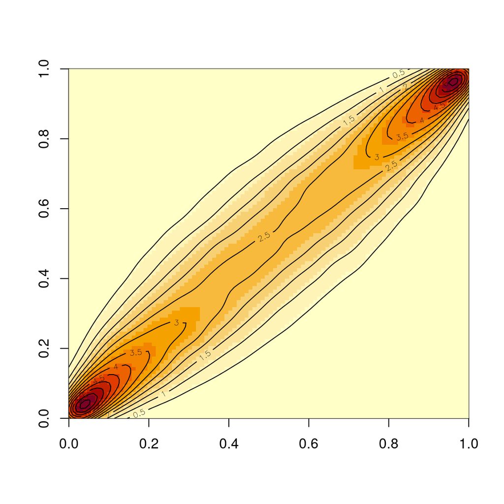

```r
image(res<-kde2d(u_normal[,1],u_normal[,2],n=100),xlim=c(0,1),ylim=c(0,1))
contour(res,add=T)
```

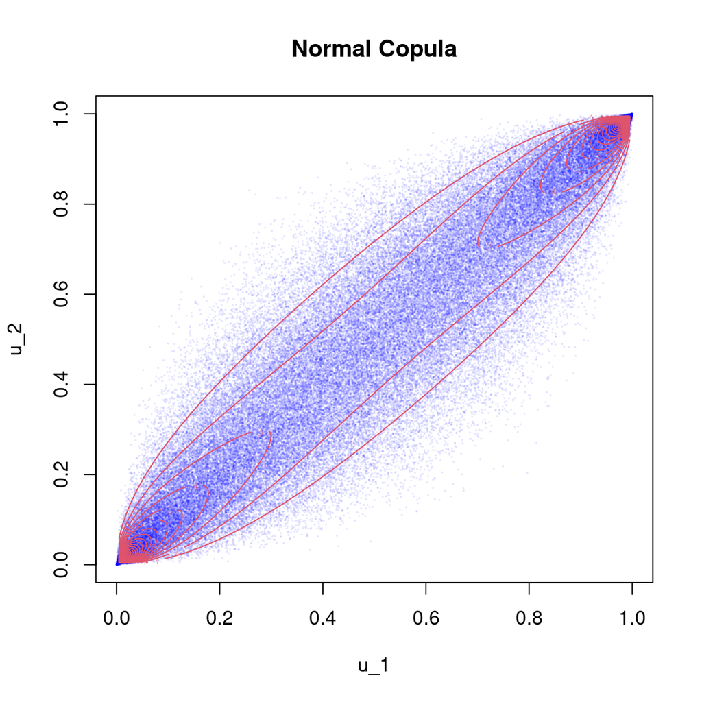

```r
plot(u_normal[,1],u_normal[,2],cex=0.1,col=rgb(0,0,1,alpha=0.1),xlab="u_1",ylab="u_2",main="Normal Copula")
contour(u1,u2,z_normal,nlevels=50,add=TRUE,col=2)
```

### 5.コピュラの応用の(1)貸出ポートフォリオの信用リスク

$$X_i=\sqrt{\rho}S+\sqrt{1-\rho}\epsilon_i, S,\epsilon_i \sim
\mbox{N}(0,1^2)$$

$$\vec{x}\sim \mbox{N}_{n}(\vec{0},\Sigma)$$

$$\Sigma=\left(\begin{array}{ccccc} 1 & \rho & \rho & \cdots
& \rho \\
\rho & 1 & \rho & \cdots & \rho \\
\rho & \rho & 1 & \rho & \cdots 1 \\
\vdots & \vdots & \vdots & \ddots & \vdots \\
\rho & \rho & \rho & \cdots & 1
\end{array}\right)$$

```r
rmvnorm_1factor<-function(n,rho) sqrt(rho)*rnorm(1)+sqrt(1-rho)*rnorm(n)
normal_copula_1factor<-function(n,rho) pnorm(rmvnorm_1factor(n,rho))
```

```r
rho<-0.2
pd<-0.005
N_defaults_normal<-c()
for(i in 1:1e5) N_defaults_normal[i]<-sum(normal_copula_1factor(1e4,rho)<pd)
```

```r
quantile(N_defaults_normal,probs=c(0.001,0.01,0.05,0.1,0.5,0.9,0.95,0.99,0.999))
```

```
##    0.1%      1%      5%     10%     50%     90%     95%     99%   99.9%
##   0.000   0.000   1.000   2.000  20.000 125.000 198.000 420.000 917.001
```

### (2) tコピュラ

- $t^{n}_{\nu,\Sigma}(\vec{x})$:自由度$\nu$、相関行列$\Sigma$の$n$変量$t$分布の分布関数
- $t_{\nu}(t)$：自由度$\nu$の1変量$t$分布の分布関数

$$C^{n}_{\nu,\Sigma}(\vec{u})=t^{n}_{\nu,\Sigma}(t_{\nu}^{-1}(u_1),\cdots,t_{\nu}^{-1}(u_n)),\nu\ge
3$$

- $n$変量$t$分布の分布関数

$$t_{\nu,\Sigma}^{n}(x_1,\cdots,x_n)=\frac{\Gamma\left(\frac{\nu+n}{2}\right)}{\Gamma\left(\frac{\nu}{2}\right)
(\nu \pi)^{\frac{n}{2}}\sqrt{|\Sigma|}}\int_{-\infty}^{x_1}\cdots
\int_{-\infty}^{x_n}\left(1+\frac{1}{\nu}\vec{x}^{T}\Sigma^{-1}\vec{x}\right)^{-\frac{\nu+n}{2}}d\vec{x}$$

- $t$コピュラの密度関数は(3)より,$\vec{\omega}^{T}=(t_{\nu}^{-1}(u_1),\cdots,t_{\nu}^{-1}(u_n))$として

$$c(u_1,\cdots,u_n;\Sigma,\nu)=\frac{\Gamma(\frac{\nu+n}{2})[\Gamma(\frac{\nu}{2})]^n(1+\frac{1}{\nu}\vec{\omega^{T}\Sigma^{-1}\vec{\omega}})^{-\frac{\nu+n}{2}}}{\sqrt{|\Sigma|}\Gamma(\frac{\nu}{2})[\Gamma(\frac{\nu+1}{2})]^n\prod_{i=1}^{n}(1+\frac{\omega_i^2}{\nu})^{-\frac{\nu+1}{2}}}$$

#### 裾の依存

$$\lambda_U=2\left(1-t_{\nu+1}\left(\sqrt{\frac{(1-\rho)(\nu+1)}{1+\rho}}\right)\right)$$

$$\lambda_U=2\left(-t_{\nu+1}\left(\sqrt{\frac{(1-\rho)(\nu+1)}{1+\rho}}\right)\right)$$

#### tコピュラに従う乱数$\vec{u}$の生成方法

- (1)相関行列$\Sigma$を持つ$n$変量正規乱数$Y_1,\cdots,Y_n$を生成
- (2)自由度$\nu$の$\chi^2$分布に従う乱数$Z$を生成
- (3)$X_i=Y_i/\sqrt{Z/\nu}$
- (4)$U_i=t_{\nu}(X_i)$

#### Rでのシミュレーション

```r
library(mvtnorm)
n<-1e5
rho<-0.9239
nu<-3
tau<-(2/pi)*asin(rho)
sigma<-matrix(c(1,rho,rho,1),ncol=2)
x<-rmvt(n,sigma=sigma,df=nu)
rho;tau
```

```
## [1] 0.9239
```

```
## [1] 0.7500341
```

```r
u_t<-cbind(pt(x[,1],nu),pt(x[,2],3))
```

$$c(u_1,u_2;\Sigma,\nu)=\frac{dt^2_{\nu,\Sigma}(t_{\nu}^{-1}(u_1),t_{\nu}^{-1}(u_2))}{dt_{\nu}(t_{\nu}^{-1}(u_1))dt_{\nu}(t_{\nu}^{-1}(u_2))}$$

```r
t_copula<-function(u1,u2,rho,nu) dmvt(x=c(qt(u1,nu),qt(u2,nu)),sigma=matrix(c(1,rho,rho,1),ncol=2),df=nu,log=FALSE)/(dt(qt(u1,nu),nu)*dt(qt(u2,nu),nu))
u1<-seq(0,1,length=201)
u2<-u1
f12<-function(u1,u2) Vectorize(t_copula)(u1,u2,rho,nu)
z_t<-outer(u1,u2,f12)
```

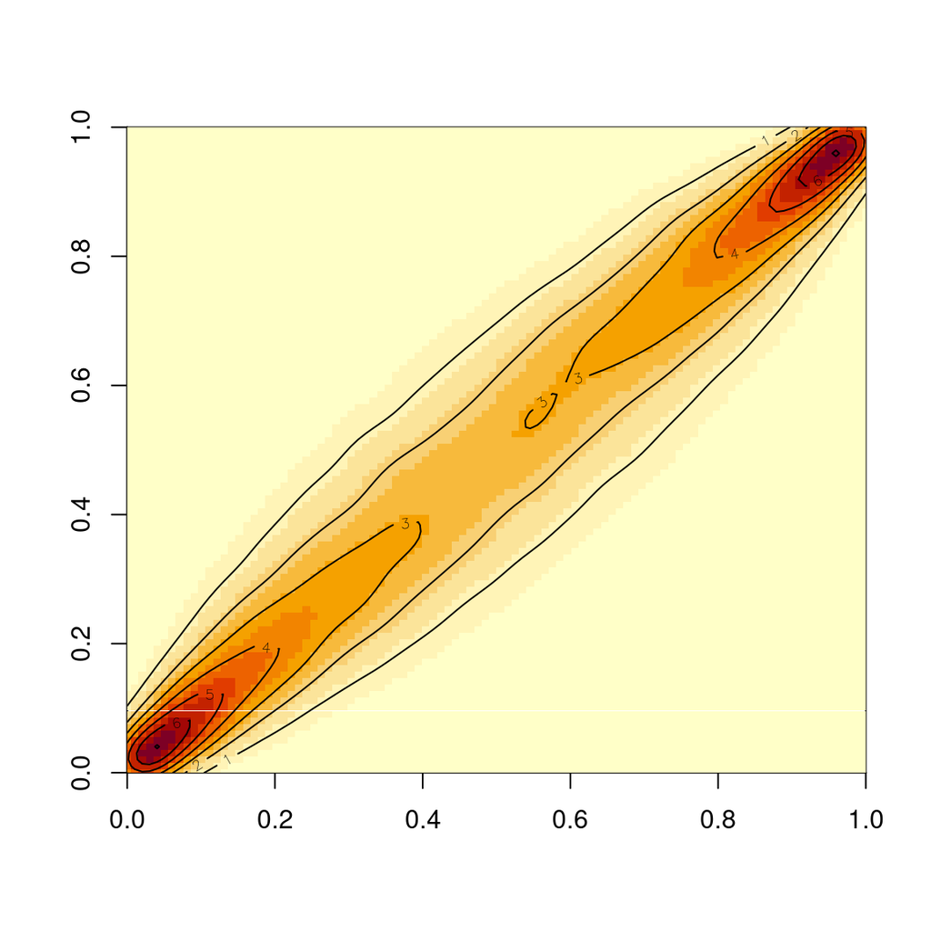

```r
image(res<-kde2d(u_t[,1],u_t[,2],n=100),xlim=c(0,1),ylim=c(0,1))
contour(res,add=T)
```

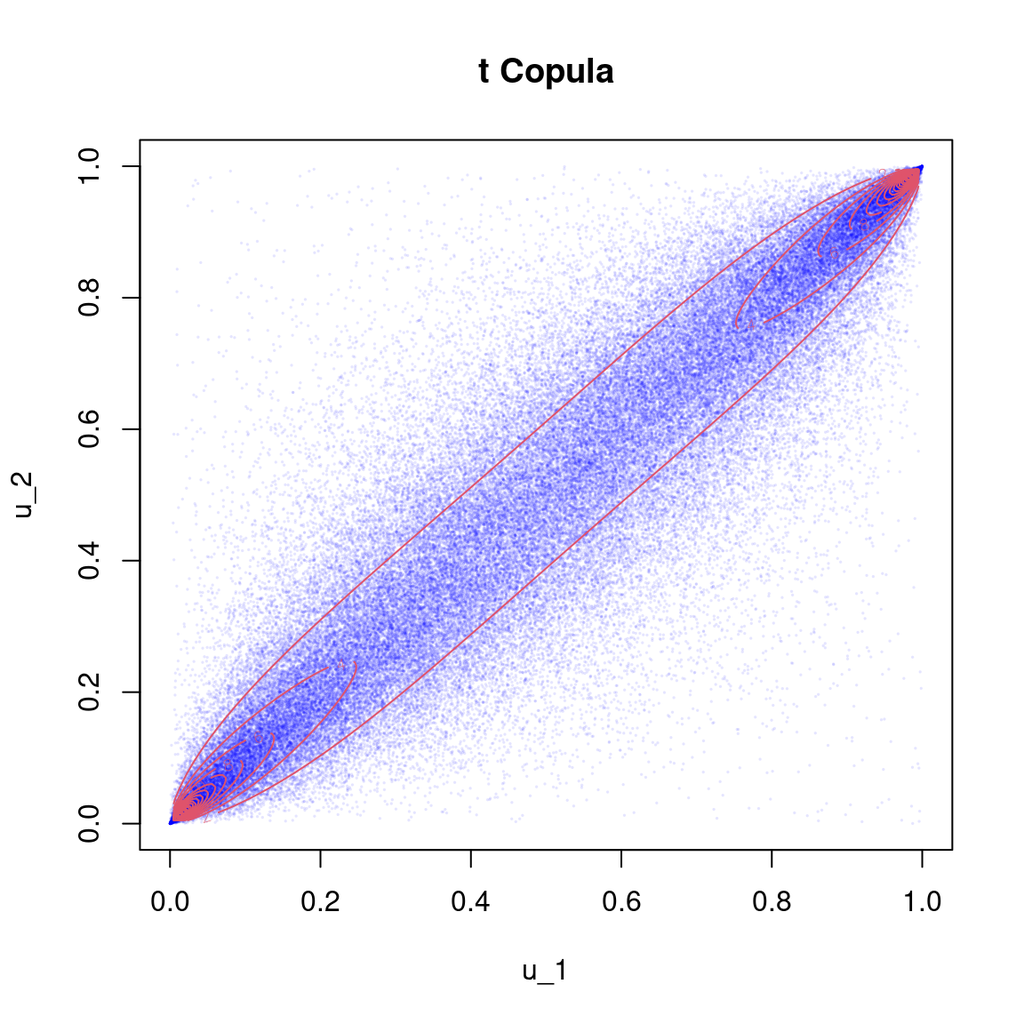

```r
plot(u_t[,1],u_t[,2],cex=0.1,col=rgb(0,0,1,alpha=0.1),xlab="u_1",ylab="u_2",main="t Copula")
contour(u1,u2,z_t,nlevels=50,add=TRUE,col=2)
```

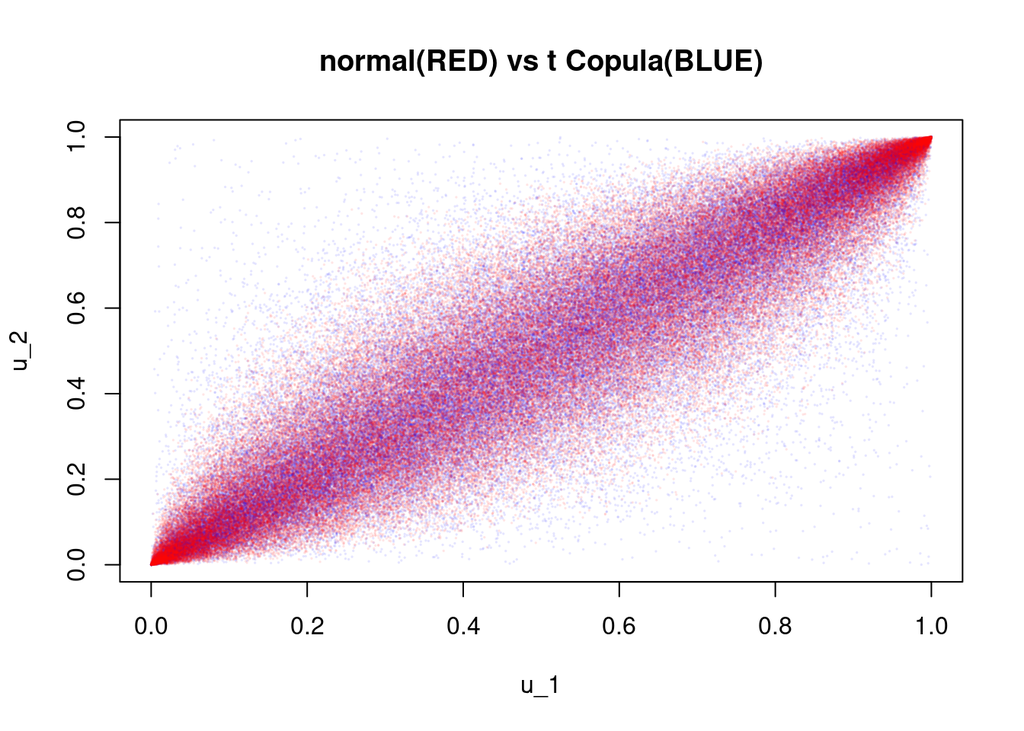

```r
plot(u_t[,1],u_t[,2],cex=0.1,col=rgb(0,0,1,alpha=0.1),xlab="u_1",ylab="u_2",main="normal(RED) vs t Copula(BLUE)")
points(u_normal[,1],u_normal[,2],cex=0.1,col=rgb(1,0,0,alpha=0.1))
```

### 5.コピュラの応用の(1)貸出ポートフォリオの信用リスク

```r
rmvt_1factor<-function(n,rho,nu) (sqrt(rho)*rnorm(1)+sqrt(1-rho)*rnorm(n))/sqrt(rchisq(1,nu)/nu)
t_copula_1factor<-function(n,rho,nu) pt(rmvt_1factor(n,rho,nu),nu)
```

```r
rho<-0.2
pd<-0.005
nu<-10
N_defaults_t<-c()
for(i in 1:1e5) N_defaults_t[i]<-sum(t_copula_1factor(1e4,rho,nu)<pd)
```

```r
quantile(N_defaults_t,probs=c(0.001,0.01,0.05,0.1,0.5,0.9,0.95,0.99,0.999))
```

```
##     0.1%       1%       5%      10%      50%      90%      95%      99%
##    0.000    0.000    0.000    0.000    3.000  112.000  240.000  788.000
##    99.9%
## 2079.022
```

```r
#save(N_defaults_t,N_defaults_normal,file="20191101.RData")
```